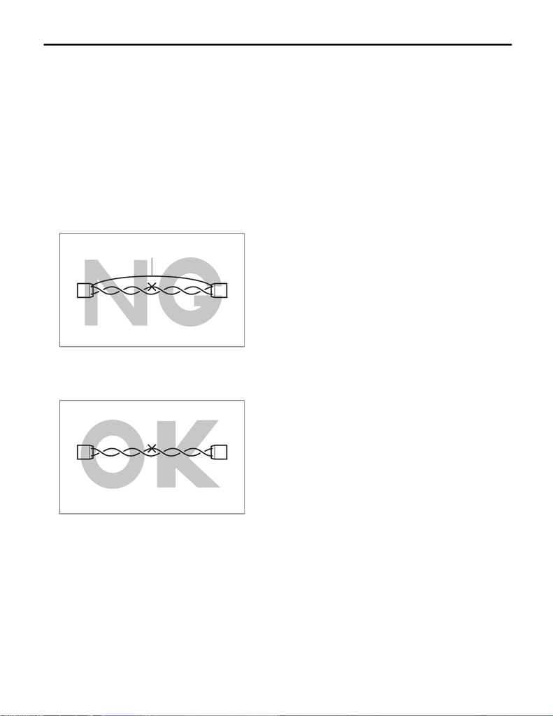

LAN(diag)-5

General Description

LAN SYSTEM (DIAGNOSTICS)

3. General Description

A: CAUTION

1. SUPPLEMENTAL RESTRAINT SYSTEM “AIRBAG”

Airbag system wiring harness is routed near the body integrated unit and twisted pair line.

CAUTION:

• Do not use the electrical test equipment on all airbag system wiring harnesses and connectors.

• Be careful not to damage the airbag system wiring harness when servicing the body integrated

unit and LAN system.

2. LAN SYSTEM

• Bus line of LAN system is twisted pair line. Be careful not to by-pass or partly unbind the twisted pair line.

• Do not make clearance between bus lines (CAN High, CAN Low).

• Difference of bus line length should be within 10 cm (3.94 in).

• Fray near the connector should be within 8 cm (3.14 in).

• If the characteristics of the twisted pair line are changed, it may extremely weaken against noise.

• When repairing the harness, connect the wires using soldering and protect it with insulating tape etc.

LAN00225

(A)

(A) Bypass wire connection

LAN00224

(A)

(A) Soldering and protection with insulating tape

[figure not shown]

LAN(diag)-6

General Description

LAN SYSTEM (DIAGNOSTICS)

3. TIME STAMP

There are three types of record data for the information of time stamp, and they are stored together with di-

agnostic codes.

NOTE:

Depending on DTCs, time stamp may not be stored.

a. Trip Count

This indicates the number of times that the ignition has been turned to ON since the vehicle was manufac-

tured. The ignition ON count of when the diagnostic code is stored is displayed on the diagnostic code check

screen.

NOTE:

Subaru Select Monitor screen (A/C system diagnostic code and time stamp)

The current Trip Count can be checked at “Current Data Display & Save” in “Integ. unit mode”.

By comparing the current Trip Count and the Trip Count of when the diagnostic code was stored, it is possible

to determine that it is how many ignition-ON operations ago that DTC was stored.

b. Time Count

The elapsed time from when the ignition is turned to ON to when the diagnostic code is stored is displayed

on the diagnostic code check screen. It is possible to determine the length of time that passed between when

the user started driving and when the diagnostic code was stored. Therefore, if Trip Count until the vehicle-

received-date is determined by interviewing the user, it is possible to estimate where the user was driving

when the diagnostic code was stored, using the information such as Trip Count and Time Count. This esti-

mate is useful information to perform diagnosis including checking of repeatability.

NOTE:

Subaru Select Monitor screen (A/C system diagnostic code and time stamp)

When multiple diagnostic codes are recorded for one trouble, it is extremely important to determine the di-

agnostic code that was stored first. (It is important to perform the diagnosis for the first recorded diagnostic

code.) In this case, it is also possible to immediately determine which diagnostic code was recorded first, us-

ing the information such as Trip Count and Time Count.

Code Description & trouble position

Trouble

occurrence

record

Trip Count Time Count Count

B14E1 Air Mix Door Actuator Stepping Motor Cir-

cuit Wire Break (Driver’s Seat)

Detected on

the first time

983 18000 Common

B14E7 Heater Core Rear Sensor Circuit Wire

Break

Detected on

the 2nd time

984 117800 Common

occurrence

record

Trip Count Time Count Count

B14E1 Air Mix Door Actuator Stepping Motor Cir-

cuit Wire Break (Driver’s Seat)

Detected on

the first time

983 18000 Common

B14E7 Heater Core Rear Sensor Circuit Wire

Break

Detected on

the 2nd time

[figure not shown]

LAN(diag)-7

General Description

LAN SYSTEM (DIAGNOSTICS)

c. Count

Each unit individually counts the elapsed time since the ignition is turned to ON. However, these time counts

may have some errors, and therefore, the control modules need to be adjusted to the time carried by the

master-time unit (the body integrated unit). When the count is set as common, it means that each control

module is already adjusted to the master time, and the display for the master integrated unit is always indi-

cated as “Common”. When the count is indicated as “Originally”, it means that the time is not synchronized

with the master time. In this case, check the communication between the corresponding control module and

integrated unit. When all controls other than the body integrated unit is indicated as “Originally”, perform the

basic inspection for the body integrated unit. <Ref. to BC(diag)-2, PROCEDURE, Basic Diagnostic Proce-

dure.>

NOTE:

Subaru Select Monitor screen (A/C system diagnostic code and time stamp)

Even when multiple diagnostic codes are stored in multiple control modules, it is possible to determine the

code stored first through the count function.

NOTE:

Troubleshooting for CAN system U-code occurrence

When the first stored diagnostic code is a U-code for CAN system, perform the troubleshooting as a U code

combination, instead of a U code alone. In addition, when CAN open circuit occurs, communication of the di-

agnostic device itself becomes impossible beyond the particular areas. However, trouble positions can also

be determined by the combination of initial communication success/failure. Thus, by performing the basic di-

agnostic procedure in LAN system, trouble positions can be determined efficiently on the principle above.

<Ref. to LAN(diag)-2, PROCEDURE, Basic Diagnostic Procedure.>

B: INSPECTION

1. INSPECTION WITHOUT USING CAN DIAGNOSTIC

Before performing diagnosis, check the following items that might affect troubles of each module.

1) Measure the battery voltage and check electrolyte.

Standard voltage: 12 V or more

Specific gravity: 1.260 or more

2) Check the fuse condition.

Make sure that ampere of the fuse is setting value, and it is not blown out.

3) Check the connecting condition of harness and harness connector.

2. INSPECTION USING CAN DIAGNOSTIC

Before performing diagnostics, check the following item which might affect body integrated unit malfunctions.

1) Confirm settings of body integrated unit are corresponded to vehicle equipment. <Ref. to BC(diag)-22,

OPERATION, Registration Body Integrated Unit.>

2) Make sure that the User Customizing of the body integrated unit matches the vehicle equipment. <Ref. to

BC(diag)-20, OPERATION, User Customizing.>

3) Confirm “Factory initial setting” of body integrated unit registrations is set to “Market”.

occurrence

record

Trip Count Time Count Count

cuit Wire Break (Driver’s Seat)

Detected on

the first time

B14E7 Heater Core Rear Sensor Circuit Wire

Break

Detected on

the 2nd time

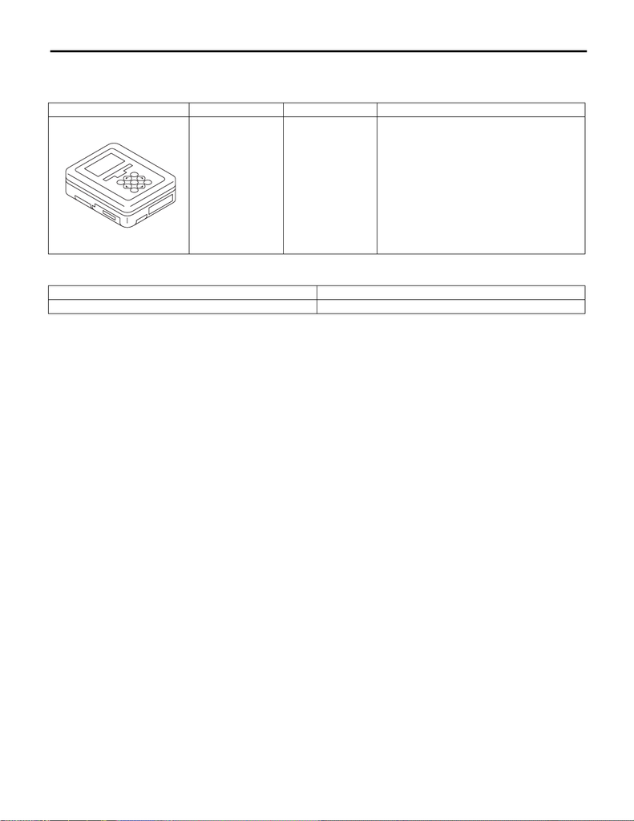

LAN(diag)-8

General Description

LAN SYSTEM (DIAGNOSTICS)

C: PREPARATION TOOL

1. SPECIAL TOOL

2. GENERAL TOOL

ILLUSTRATION TOOL NUMBER DESCRIPTION REMARKS

1B022XU0 SUBARU SELECT

MONITOR III KIT

Used for troubleshooting the electrical system.

TOOL NAME REMARKS

Circuit tester Used for measuring resistance, voltage and current.

ST1B022XU0